# Renny_Oyelahan_Project_2

## Variable Transformations

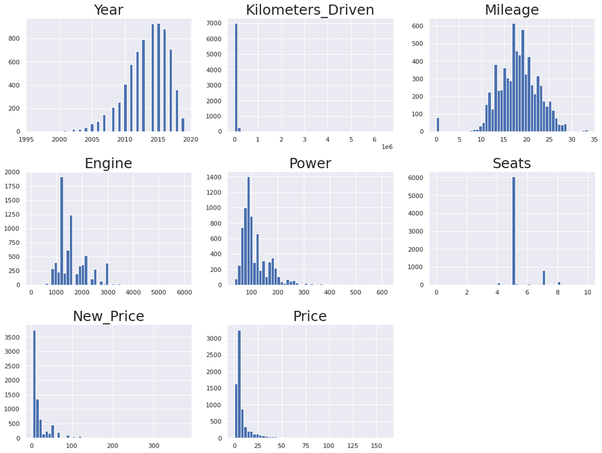

```python
# creating a list of non-tag columns
dist_cols = [
    item for item in df.select_dtypes(include=np.number).columns if "tag" not in item
]

# let's plot a histogram of all non-tag columns

plt.figure(figsize=(15, 45))

for i in range(len(dist_cols)):
    plt.subplot(12, 3, i + 1)
    plt.hist(df[dist_cols[i]], bins=50)
    # sns.histplot(data=df, x=dist_cols[i], kde=True)  # you can comment the previous line and run this one to get distribution curves
    plt.tight_layout()
    plt.title(dist_cols[i], fontsize=25)

plt.show()
```

- We see that most of the columns have a very skewed distribution.
- **We will apply the log transformation to all but the `S.No. column to deal with skewness in the data.**

```python
# using log transforms on some columns

for col in dist_cols:
    df1[col + "_log"] = np.log(df1[col] + 1)

# dropping the original columns
df1.drop(dist_cols, axis=1, inplace=True)
df1.head()
```

|  | Name | Fuel_Type | Transmission | Owner_Type | Year_log | Kilometers_Driven_log | Mileage_log | Engine_log | Power_log | Seats_log | New_Price_log | Price_log |
| --- | --- | --- | --- | --- | --- | --- | --- | --- | --- | --- | --- | --- |
| 0 | Maruti Wagon R LXI CNG | CNG | Manual | First | 7.606387 | 11.184435 | 3.317816 | 6.906755 | 4.080246 | 1.791759 | 1.873339 | 1.011601 |
| 1 | Hyundai Creta 1.6 CRDi SX Option | Diesel | Manual | First | 7.608871 | 10.621352 | 3.028683 | 7.367077 | 4.845761 | 1.791759 | 2.836737 | 2.602690 |
| 2 | Honda Jazz V | Petrol | Manual | First | 7.606885 | 10.736418 | 2.954910 | 7.090077 | 4.496471 | 1.791759 | 2.262804 | 1.704748 |
| 3 | Maruti Ertiga VDI | Diesel | Manual | First | 7.607381 | 11.373675 | 3.080533 | 7.130099 | 4.497139 | 2.079442 | 2.507157 | 1.945910 |
| 4 | Audi A4 New 2.0 TDI Multitronic | Diesel | Automatic | Second | 7.607878 | 10.613271 | 2.785011 | 7.585281 | 4.954418 | 1.791759 | 3.991573 | 2.930660 |

**Let's check for skewness after applying the log transformation.**

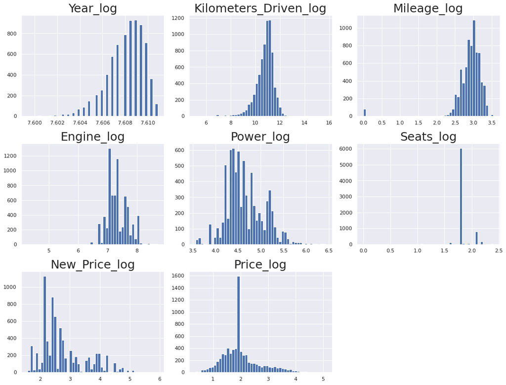

```python
# creating a list of non-tag columns
dist_cols = [
    item for item in df1.select_dtypes(include=np.number).columns if "tag" not in item
]

# let's plot histogram of all non-tag columns

plt.figure(figsize=(15, 45))

for i in range(len(dist_cols)):
    plt.subplot(12, 3, i + 1)
    plt.hist(df1[dist_cols[i]], bins=50)
    # sns.histplot(data=df1, x=dist_cols[i], kde=True)  # you can comment the previous line and run this one to get distribution curves
    plt.tight_layout()
    plt.title(dist_cols[i], fontsize=25)

plt.show()
```

- There has been some improvement in the skewness of the columns, but the columns are still skewed.

**Let's check for correlations between the columns (other than the tag columns)**

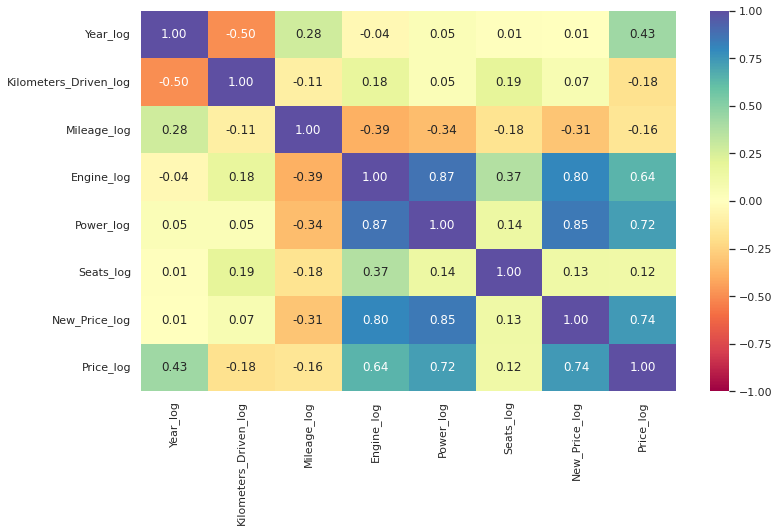

```python
plt.figure(figsize=(12, 7))
sns.heatmap(
    df1[dist_cols].corr(), annot=True, vmin=-1, vmax=1, fmt=".2f", cmap="Spectral"
)
plt.show()
```

There are a few highly correlated columns